# Project: Investigate TMDB movies data

- Introduction
- Data Wrangling
- Exploratory Data Analysis
- Conclusions

## Introduction

This data set contains information about 10,866 movies collected from The Movie Database (TMDb), including user ratings and revenue. Which genres are most popular from year to year? Does a higher budget correspond to higher user rating? What kinds of properties are associated with movies that have high revenues?

```python
import os
import pandas as pd
import numpy as np
# Adding libraries

HOME = os.path.expanduser("~")
DIR = HOME + "/Desktop/Week_4_Workbook"

os.chdir(DIR)
print('Your current working directory: \n', os.getcwd())
print('\nContents in your curent working directory: \n', os.listdir("."))
# Verifying correct connection to local folder
```

```
Your current working directory:
 /Users/alexia/Desktop/Week_4_Workbook

Contents in your curent working directory:
 ['.ipynb_checkpoints', 'AmazingMartEU2.xlsx', 'countries_info.csv', 'Investigate_TMDB.ipynb', 'life_expectancy.csv', 'numpy_pandas_cheatsheet.pdf', 'nyc_subway_weather.csv', 'test_file.txt', 'tmdb-movies.csv', 'Week_4_Lesson_Solutions_Updated.ipynb', 'Week_4_Workbook.ipynb']
```

## Data Wrangling

The above code verified our contection to the correct directory, containing the tmdb-movies CSV file. Now that we can access the file, let's read it into a Pandas DataFrame and look at some of the data.

### General Properties

```python
# Importing movie data into a Pandas dataframe named tmdb_movies_df

tmdb_movies_df = pd.read_csv("tmdb-movies.csv")
print("Column values for the dataframe: \n", tmdb_movies_df.columns.values)

# Verifying column names were read in correctly. Then count the number of movie entries.
total_movie_count = tmdb_movies_df.id.count()
print(total_movie_count)
```

```
Column values for the dataframe:
 ['id' 'imdb_id' 'popularity' 'budget' 'revenue' 'original_title' 'cast'
 'homepage' 'director' 'tagline' 'keywords' 'overview' 'runtime' 'genres'
 'production_companies' 'release_date' 'vote_count' 'vote_average'
 'release_year' 'budget_adj' 'revenue_adj']
10866
```

### Some details

We've verified that the file was read into our DataFrame, by viewing the headings of the columns and counting the number of ids—10,866. Let's get to know our data by taking a deeper look.

```
Highests user rated movie:  [[125336 'The Story of Film: An Odyssey' 'Documentary' '9/3/11' 9.2 0.0]]
Lowest user rated movie:  [[22293 'Manos: The Hands of Fate' 'Horror' '11/15/66' 1.5 127642.279153664]]
```

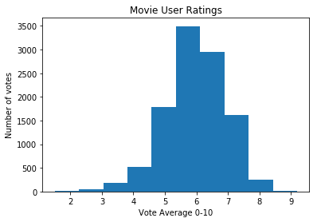

```python
# Adding libraries for plotting graphs
import scipy.stats as st
import matplotlib.pyplot as plt
import seaborn as sns
%matplotlib inline

sorted_by_vote_df = tmdb_movies_df.sort_values('vote_average', ascending=False)
highest_vote = sorted_by_vote_df['vote_average'].argmax()
select_stats = ['id', 'original_title', 'genres', 'release_date', 'vote_average', 'budget_adj']

# Print some information about the lowest and highest rated movies
print("Highests user rated movie: ", sorted_by_vote_df[0:1][select_stats].values)
print("Lowest user rated movie: ", sorted_by_vote_df[-1:][select_stats].values)

# Plot the histogram
plt.hist(tmdb_movies_df['vote_average'])
plt.title("Movie User Ratings")
plt.xlabel("Vote Average 0-10")
plt.ylabel("Number of votes")
plt.show()
```

We see that each movie has an average users rating, called 'vote_average', but some movies do not have a value for the adjusted budget (unless many of these movies were made for free!). Notably, the highest rated movie, with a 9.2 average, has a budget of 0.0. If we want to consider the movie budgets in our investigation we'll have to get rid of the entries with missing budget values.

### Data Cleaning (a.k.a. finding movies with a budget)

```python
# Remove movies in the 'Documentary' genre
not_documentaries_df = sorted_by_vote_df.loc[~sorted_by_vote_df.genres.str.contains('Documentary',na=False)]

# Remove movies that do not
with_budget_df = sorted_by_vote_df.loc[sorted_by_vote_df.budget_adj.values > 0.000000e+00]

print(with_budget_df[0:]['vote_average'].values)
print(with_budget_df.loc[with_budget_df.vote_average==8.4][select_stats].values)
```

```
[ 8.4  8.4  8.4 ...,  2.4  2.2  1.5]
[[24128 'Stop Making Sense' 'Documentary|Music' '11/16/84' 8.4
  2518850.44703298]
 [278 'The Shawshank Redemption' 'Drama|Crime' '9/10/94' 8.4
  36777789.039954]
 [242575 'Guten Tag, RamÃ³n' 'Drama' '10/18/13' 8.4 3744133.41096169]]
```

Above, we've discovered how to factor out movies by genre ('Documentary' in this example) for later use and we've got a new dataframe containing movies with a budget greater than 0. Printing our vote average now, we see the highest score of 9.2 has been factored out, but our last place winner, with a 1.5, is hanging in there. Now, the three highest ranking films share a vote_average of 8.4.

## Exploratory Data Analysis

### Plotting the Adjusted Budget vs. User Rating

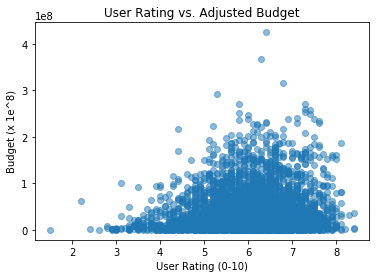

```
The mean vote average (user rating):  6.03210831721467

Standard dev of user rating: 0.8841558006650004
```

```python
# Testing scatter plot
#N = 500
x = with_budget_df[0:]['vote_average'].values
y = with_budget_df[0:]['budget_adj'].values
#colors = np.random.rand(50) # Couldn't get the random colors to work in this context
#area = np.pi * (15 * np.random.rand(50))**2  # 0 to 15 point radii
# This area feature could be manipulated to reflect the budget of the movie, with costlier being wider dots

plt.scatter(x, y, alpha=0.5)
plt.title("User Rating vs. Adjusted Budget")
plt.xlabel("User Rating (0-10)")
plt.ylabel("Budget (x 1e^8)")
plt.show()

vote_mean = with_budget_df[0:].vote_average.mean()
vote_std = with_budget_df[0:].vote_average.std()
print("The mean vote average (user rating): ", vote_mean)
print("\nStandard dev of user rating:", vote_std)
```

We've plotted all the movies, by user rating, on a scatter chart with that movie's budget. We're exploring the relationship between spending more to make a movie and how much the audience enjoys that movie. We found the mean user rating, about 6, and its standard deviation, 0.884. Let's examine the values within 1 standard deviation of the mean to look for budget trends.

### Research Question 1: Does spending more money on your film increase the chance of high ratings?

Remember that we removed movies that did not list an adjusted budget which reduced the sample size. We're going to narrow in further by looking at plus or minus one standard deviation.

```python
above_one_std_df = with_budget_df.loc[with_budget_df.vote_average.values >= 5.2]
below_one_std_df = with_budget_df.loc[with_budget_df.vote_average.values <= 6.9]
# Merge the DataFrames into one DataFrame that contains movies ranking between 1 standard deviation of the mean.
DF_merged = above_one_std_df.merge(below_one_std_df, how='inner', left_index=True, right_index=True)
# Now that we've merged the column names have an _x and _y added
print("Get summary stats for +-1 sigma\n",DF_merged.budget_adj_y.describe())
```

```
Get summary stats for +-1 sigma
 count    3.647000e+03
mean     3.886636e+07
std      4.217681e+07
min      9.693980e-01
25%      9.631181e+06
50%      2.531967e+07
75%      5.301325e+07
max      4.250000e+08
Name: budget_adj_y, dtype: float64
```

Because these budgets vary widely, we can't say there is any correspondence between the user rating and the ajusted budget.

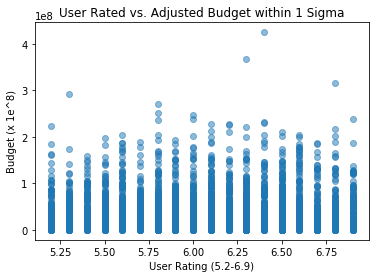

```python
x = DF_merged['vote_average_y'].values
y = DF_merged['budget_adj_y'].values
plt.scatter(x, y, alpha=0.5)
plt.title("User Rated vs. Adjusted Budget within 1 Sigma")
plt.xlabel("User Rating (5.2-6.9)")
plt.ylabel("Budget (x 1e^8)")
plt.show()
```

This graph shows that across user ratings (from 5.2 to 6.9) the budget varies from less than one million dollars to over 425 million dollars. There is no apparent correlation between the budget and the user rating.

### Research Question 2: Which genres were popular in 2014 and 2015?

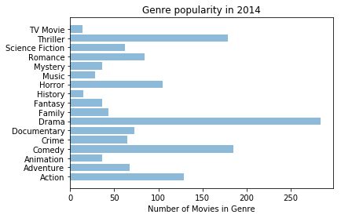

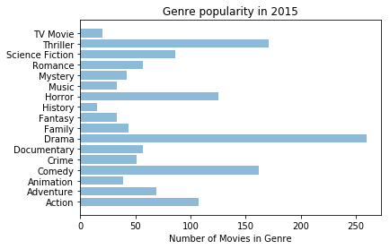

```python
sort_values = ['release_year', 'release_date']
sorted_release_df = tmdb_movies_df.sort_values(sort_values, ascending=False)

since_2014_df = sorted_release_df.loc[sorted_release_df.release_year.values == 2014]
since_2015_df = sorted_release_df.loc[sorted_release_df.release_year.values == 2015]

# Now count the entries for each genre and store the total amount for 2014 and 2015 in dictionaries
genre_names = ['Action', 'Adventure', 'Animation', 'Comedy', 'Crime', 'Documentary', 'Drama', 'Family', 'Fantasy', 'History', 'Horror', 'Music', 'Mystery', 'Romance', 'Science Fiction', 'Thriller', 'TV Movie']
genre_counts_2014 = []
genre_counts_2015 = []

for name in genre_names:
    genre_counts_2014.append(since_2014_df.genres.str.contains(name, case=True, flags=0, na=None).sum())
# print(genre_counts)

for name in genre_names:
    genre_counts_2015.append(since_2015_df.genres.str.contains(name, case=True, flags=0, na=None).sum())

y_pos = np.arange(len(genre_names))
iterations = genre_counts_2014
plt.barh(y_pos, iterations, align='center', alpha=0.5)
plt.yticks(y_pos, genre_names)
plt.xlabel('Number of Movies in Genre')
plt.title('Genre popularity in 2014')
plt.show()

iterations2 = genre_counts_2015
plt.barh(y_pos, iterations2, align='center', alpha=0.5)
plt.yticks(y_pos, genre_names)
plt.xlabel('Number of Movies in Genre')
plt.title('Genre popularity in 2015')
```

Now, let's combine the two graphs to show the change in genre popularity between 2014 and 2015.

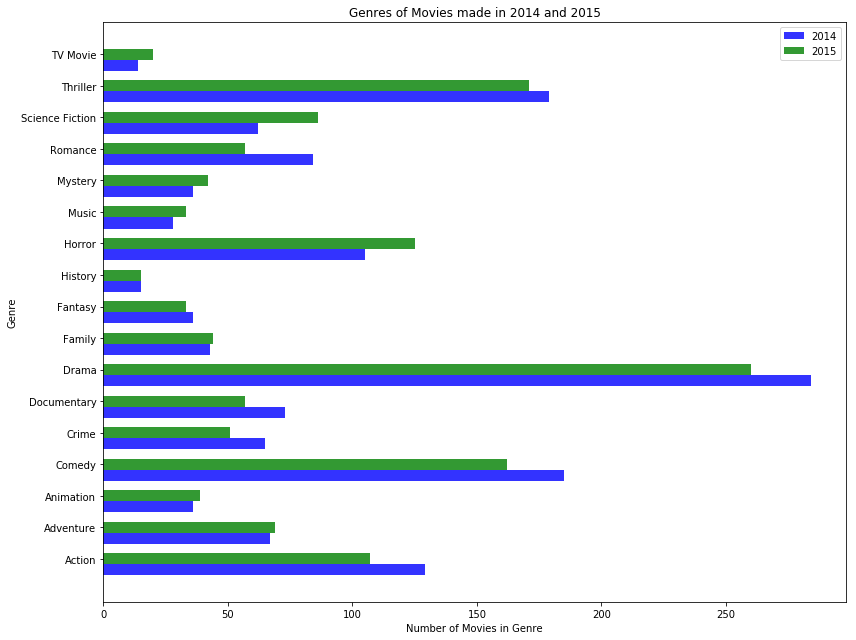

```python
# create double histogram, plotting both years side-by-side
fig, ax = plt.subplots()
index = np.arange(len(genre_names))
bar_width = 0.35
opacity = 0.8

rects1 = plt.barh(index, genre_counts_2014, bar_width,
                 alpha=opacity,
                 color='b',
                 label='2014')

rects2 = plt.barh(index + bar_width, genre_counts_2015, bar_width,
                 alpha=opacity,
                 color='g',
                 label='2015')
plt.rcParams["figure.figsize"] = [24, 18]
plt.xlabel('Number of Movies in Genre')
plt.ylabel('Genre')
plt.title('Genres of Movies made in 2014 and 2015')
plt.yticks(index + bar_width, genre_names)
plt.legend()

plt.tight_layout()
plt.show()
```

With the histograms side-by-side, we can see clearly the difference in the number of movies in each genre produced each year. The only genre to stay the same was History. 2014 out-paced the following year with Romance, Drama, Documentary, Comedy, and Action movies while the Horror and Science Fiction genres experienced significant increases in 2015.

## Conclusions

For question 1, does spending more money on your film increase the chance of high ratings, there appears to be no apparent correlation between the budget and the user rating. For question 2, which genres were popular in 2014 and 2015, we examined a histogram to draw some general conclusions. 2014 had more Romance, Drama, Documentary, Comedy, and Action movies. 2015 had move Horror and Science Fiction movies.

```python
from subprocess import call
call(['python', '-m', 'nbconvert', 'Investigate_a_Dataset.ipynb'])
```

```
255
```